# Project 1

Alvin Thomas

9/25/2019

# Introduction

The [Urban Ministries of Durham](http://www.umdurham.org/) (UMD) fights poverty and homeless by offering food, shelter, and a future to neighbors in need. Their mission is accomplished through three primary programs: a [community shelter](http://www.umdurham.org/what-we-do/shelter.html) to house homeless neighbors, a [community cafe](http://www.umdurham.org/what-we-do/cafe.html) that provides hot and cold meals three times a day, and a [food pantry and clothing closet](http://www.umdurham.org/what-we-do/food-pantry.html).

During the 2017-2018 [fiscal year](http://umdurham.org/assets/files/UMD_2018AnnualReport_Online.pdf), UMD provided 54,378 nights of shelter to homeless neighbors (792 unique individuals), served 248,028 meals through the community cafe, and provided clothing and groceries to over 500 households per month. Importantly, they ended homelessness for 243 individuals.

In collaboration with [Biostatistics 611](https://biodatascience.github.io/datasci611/), a course titled “Introduction to Data Science” at the University of North Carolina at Chapel Hill, UMD released a dataset of services provided. This project also uses data from Durham’s Open Data [portal](https://live-durhamnc.opendata.arcgis.com/pages/community-indicators).

The purpose of this project is address how UMD’s core services have changed over time in the context of secular changes in the City of Durham. We will focus on the food pantry and clothing closet services.

# Data Processing

Here is a brief peek of the data provided by UMD.

```r
head(proj1)
```

```
## # A tibble: 6 x 18
##   Date  `Client File Nu… `Client File Me… `Bus Tickets (N… `Notes of Servi…
##   <chr>            <dbl>            <dbl>            <dbl> <chr>
## 1 1/22…              212                0               NA <NA>
## 2 1/29…              738                0               NA <NA>
## 3 1/20…             3455                0               NA <NA>
## 4 11/2…             1804            21804               NA <NA>
## 5 12/2…             1806            21806               NA <NA>
## 6 10/1…             1614            21614               NA financial refer…
## # … with 13 more variables: `Food Provided for` <dbl>, `Food
## #   Pounds` <dbl>, `Clothing Items` <dbl>, Diapers <dbl>, `School
## #   Kits` <dbl>, `Hygiene Kits` <dbl>, Referrals <chr>, `Financial
## #   Support` <dbl>, `Type of Bill Paid` <chr>, `Payer of Support` <chr>,
## #   Field1 <lgl>, Field2 <lgl>, Field3 <lgl>
```

There are several variables that do not provide data that can be used in this analysis. The variables `field1`, `field2`, and `field3` are missing for almost everyone in the dataset. The variable `clientfilemerge` is not necessary for our analysis as is `Bus Tickets (Number of)`, `Notes of Service`, `Food Provided for`, `Referrals`, `Financial Support`, `Type of Bill Paid`, and `Payer of Support`.

```r
proj1 <- proj1 %>%
  select(-starts_with("field")) %>%
  select(-matches("clientfilemerge")) %>%
  select(-one_of("Bus Tickets (Number of)","Notes of Service",
                 "Food Provided for", "Referrals", "Financial Support",
                 "Type of Bill Paid", "Payer of Support"))
```

The date variables was read in as a character vectors. We can use `lubridate` to make it date-readable. We can also plot our new variable.

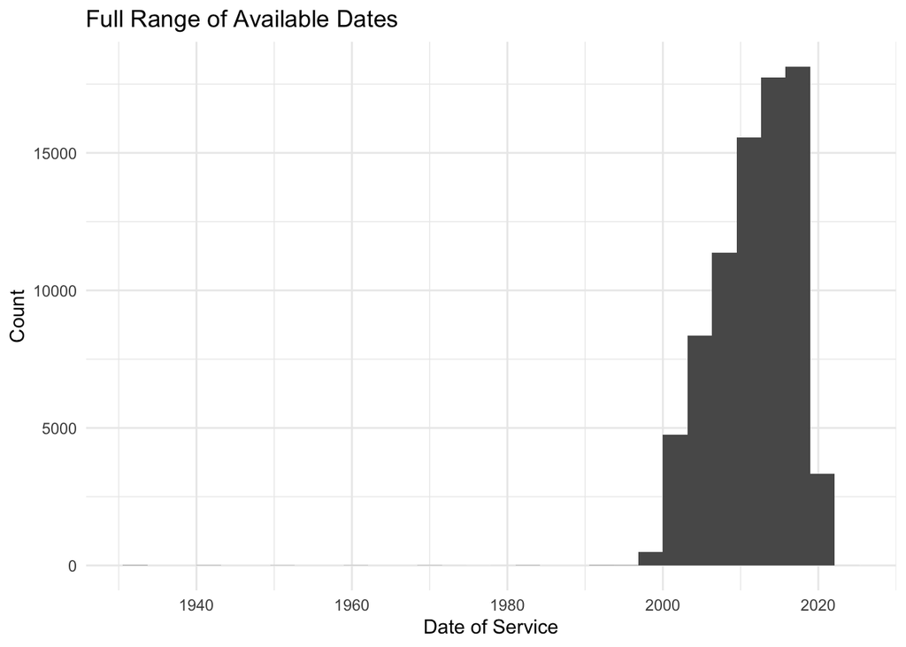

```r
proj1 <- proj1 %>%
  mutate(date_new=mdy(proj1$Date))

ggplot(data=proj1, aes(x=date_new)) +
  geom_histogram() +
  theme_minimal() +
  xlab("Date of Service") +
  ylab("Count") +
  ggtitle("Full Range of Available Dates")
```

There is probably an error with one of the dates - the entire dataset should be in the more recent era.

We will restrict analyses to the period starting in January 1, 2010 and ending December 31, 2017. This lines up with the data we have from the City of Durham Community Indicators.

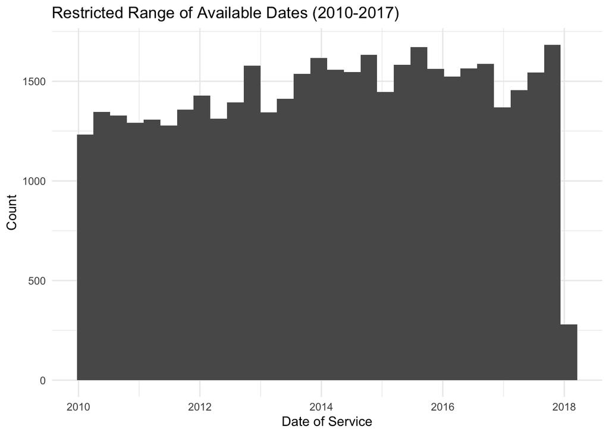

```r
proj1 <- proj1 %>%
  filter(between(date_new, as.Date("2010-01-01"), as.Date("2017-12-31"))) %>%
  arrange(date_new)

ggplot(data=proj1, aes(x=date_new)) +
  geom_histogram() +
  theme_minimal() +
  xlab("Date of Service") +
  ylab("Count") +
  ggtitle("Restricted Range of Available Dates (2010-2017)")
```

We are specifically interested in food (in lbs), items of clothing, school kits, hygiene kits, and diapers.

```r
proj1_date <- proj1 %>%
  mutate(year = year(date_new), month = month(date_new)) %>%
  group_by(year, month) %>%
  replace_na(list(`Food Pounds` = 0,
             `Clothing Items` = 0,
             `School Kits` = 0,
             `Hygiene Kits` = 0,
             Diapers = 0)) %>%
  mutate(food_cumsum = cumsum(`Food Pounds`),
        cloth_cumsum = cumsum(`Clothing Items`),
        school_cumsum = cumsum(`School Kits`),
        hygiene_cumsum = cumsum(`Hygiene Kits`),
        diaper_cumsum = cumsum(Diapers)) %>%
  summarise(food_total=max(food_cumsum, na.rm = TRUE),
            cloth_total=max(cloth_cumsum, na.rm = TRUE),
            school_total=max(school_cumsum, na.rm = TRUE),
            hygiene_total=max(hygiene_cumsum, na.rm = TRUE),
            diaper_total=max(diaper_cumsum, na.rm = TRUE))
```

Let’s peek. These are the types of graphs we would like to make.

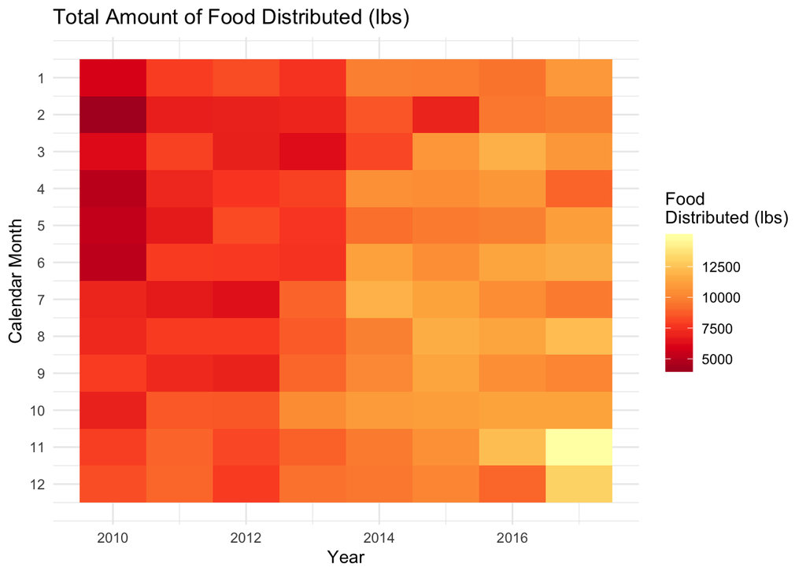

```r
proj1_date %>%
  ggplot(aes(x=year, y=month)) +
    geom_raster(aes(fill=food_total)) +
    scale_y_continuous(trans = "reverse", breaks = unique(proj1_date$month)) +
    scale_fill_distiller(palette = "YlOrRd", name="Food\nDistributed (lbs)") +
    theme_minimal() +
    xlab("Year") +
    ylab("Calendar Month") +
    ggtitle("Total Amount of Food Distributed (lbs)")
```

# Results

We were interested in the change in services at UMD over time. In order to visualize these trends, I created heatmaps (using `geom_raster`).

## Food Distribution

The amount of food delivered has increased over the years. There does not seem to be a clear visual signal of seasonal change.

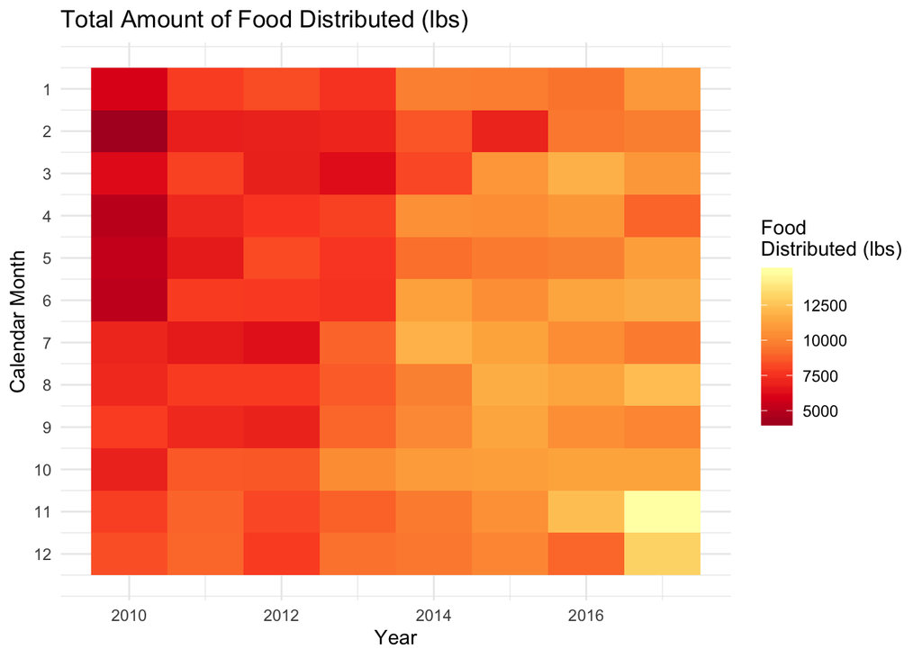

## Clothing Distribution

The amount of clothing delivered has changed over time. The peak year was 2014.

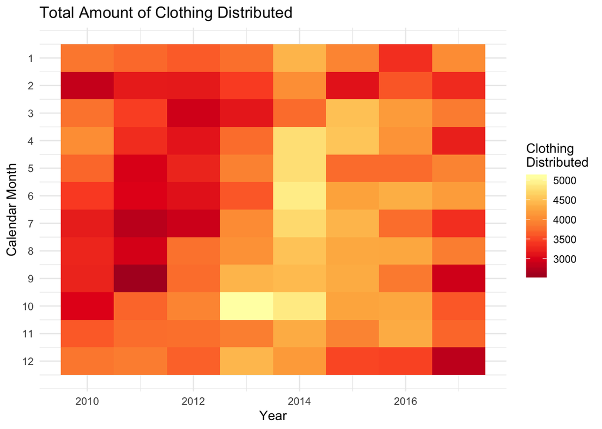

## School Kit Distribution

The quality of data on school kit distribution may be poor.

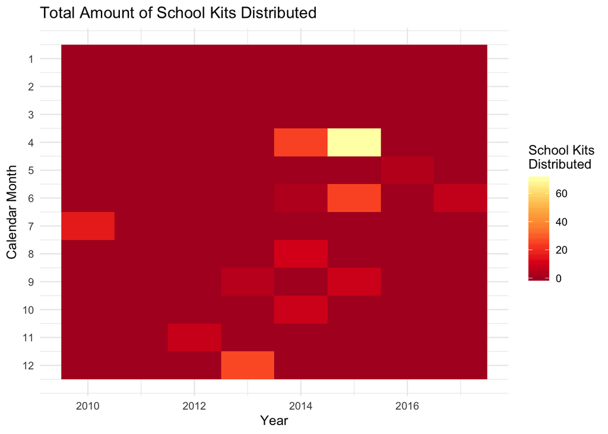

## Hygiene Kit Distribution

We know that hygiene kits are still being distributed, but the data capture on these events are poor. It appears that there have been almost no hygiene kits distributed since 2014, which we know to be false.

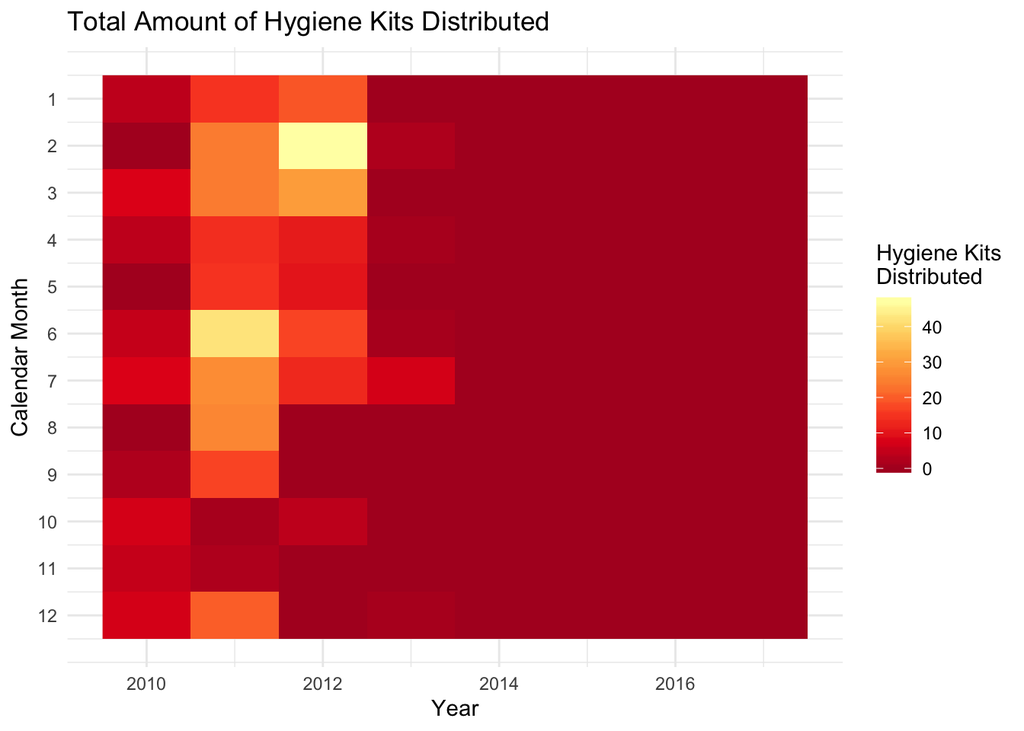

## Diaper Distribution

The quality of data on diaper distribution may be poor. There may be higher diaper distribution in the summer.

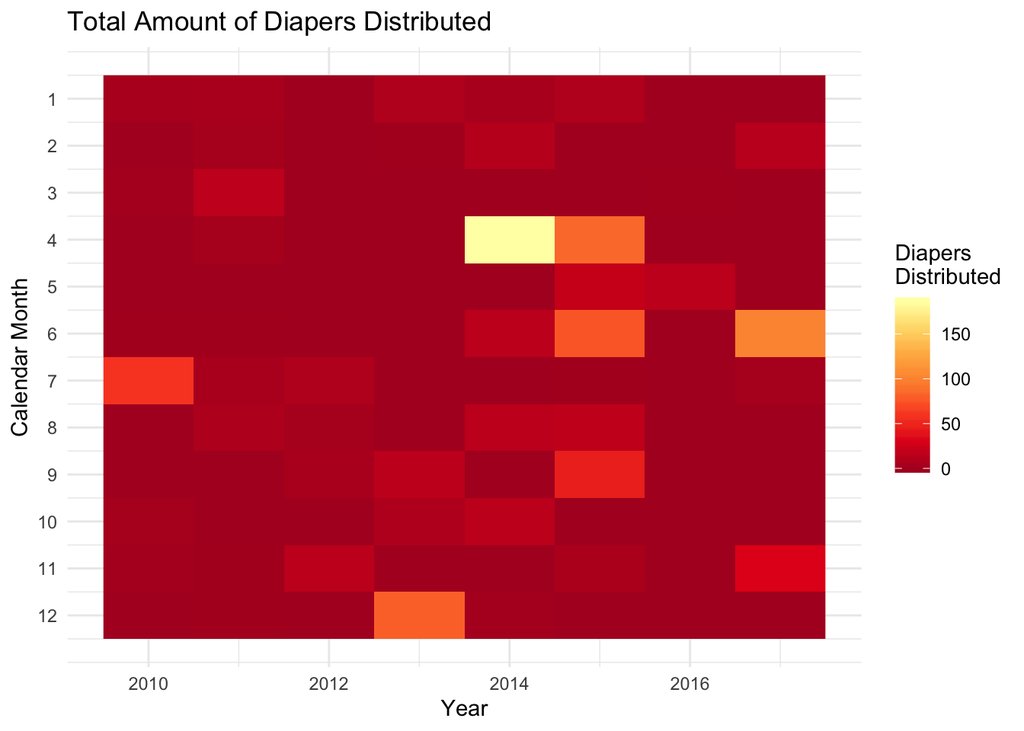

# Conclusion

The best data on changes over time in this UMD provided dataset are for food distribution. Food distribution has increased over time and does not seem to have strong seasonal variation.